# AI Computer Assignment 4 (Machine Learning)

Mohammad Saadati - *810198410*

## Introduction

The aim of this project is to get acquainted with **Machine Learning** methods through the `Sickit-Learn` library.

## Phase 0: EDA and Visualization

```python
import pandas as pd
import numpy as np
import time
import matplotlib.pyplot as plt
import seaborn as sns

dataset_df = pd.read_csv("./dataset.csv")
dataset_df
```

|  | artist_name | track_name | popularity | acousticness | danceability | duration_ms | energy | instrumentalness | key | liveness | loudness | mode | speechiness | tempo | valence | music_genre |
| --- | --- | --- | --- | --- | --- | --- | --- | --- | --- | --- | --- | --- | --- | --- | --- | --- |
| 0 | Blockhead | Cheer up, You're Not Dead Yet | 44.0 | 0.00621 | 0.711 | 285987.0 | 0.6210 | 0.029700 | G | 0.1590 | -7.429 | Major | 0.0382 | 142.065 | 0.6070 | Jazz |
| 1 | FloFilz | Corners | 34.0 | 0.34700 | 0.729 | 103703.0 | 0.5150 | 0.006920 | C | 0.1270 | -10.147 | Major | 0.1840 | 79.969 | 0.2870 | Jazz |
| 2 | Bonobo | We Could Forever | 51.0 | 0.01810 | 0.669 | NaN | 0.8850 | 0.880000 | G | 0.2650 | -7.080 | Minor | 0.0378 | NaN | 0.6360 | Jazz |
| 3 | Nils Landgren | A Child Is Born | 39.0 | 0.91800 | 0.484 | 228733.0 | 0.0693 | 0.000069 | F | 0.1390 | -15.542 | Major | 0.0346 | 82.707 | 0.2060 | Jazz |
| 4 | Masayoshi Takanaka | Samba Pati | 36.0 | 0.03450 | 0.473 | 342867.0 | 0.8230 | 0.446000 | G | 0.3060 | -6.625 | Major | 0.0630 | 104.694 | 0.3830 | Jazz |
| ... | ... | ... | ... | ... | ... | ... | ... | ... | ... | ... | ... | ... | ... | ... | ... | ... |
| 29995 | Wolfgang Amadeus Mozart | Die Zauberflöte, K. 620: Wie stark ist nicht d... | 22.0 | 0.91100 | 0.326 | 368640.0 | 0.1330 | 0.000000 | G | 0.1300 | -20.493 | Major | 0.0557 | 92.090 | 0.2060 | Classical |
| 29996 | New York Philharmonic | Symphony No. 2 in D Major, Op. 73: II. Adagio ... | 26.0 | 0.96500 | 0.126 | 514213.0 | 0.2040 | 0.869000 | B | 0.1060 | -16.474 | Major | 0.0395 | 82.437 | 0.0387 | Classical |
| 29997 | Georges Bizet | Bizet: Carmen, WD 31, Act 1 Scene 4: No. 5, Ha... | 54.0 | 0.97600 | 0.363 | 262147.0 | 0.1150 | 0.000000 | D | 0.0992 | -17.325 | Major | 0.0689 | NaN | 0.2310 | Classical |
| 29998 | Edvard Grieg | Peer Gynt-Suite Nr. 1, Op. 46: I. Morning | 42.0 | 0.98500 | 0.123 | 259573.0 | 0.0174 | 0.906000 | E | 0.1250 | -23.671 | Major | 0.0408 | 71.705 | 0.0352 | Classical |
| 29999 | Johann Sebastian Bach | Suite No. 2 in B Minor, BWV 1067: VI. Menuet | 36.0 | 0.77200 | 0.486 | 74600.0 | 0.1570 | 0.906000 | G# | 0.1470 | -19.078 | Minor | 0.0375 | 124.737 | 0.6190 | Classical |

30000 rows × 16 columns

### Question 1:

The describe() function returns descriptive statistics for every column of DataFrame.

```python
dataset_df.describe()
```

|  | popularity | acousticness | danceability | duration_ms | energy | instrumentalness | liveness | loudness | speechiness | tempo | valence |
| --- | --- | --- | --- | --- | --- | --- | --- | --- | --- | --- | --- |
| count | 30000.000000 | 30000.000000 | 30000.000000 | 2.699000e+04 | 30000.000000 | 30000.000000 | 30000.000000 | 30000.000000 | 30000.000000 | 27067.000000 | 30000.000000 |
| mean | 47.769533 | 0.359661 | 0.540929 | 2.466460e+05 | 0.556709 | 0.180807 | 0.183610 | -10.079862 | 0.083861 | 117.559824 | 0.446563 |
| std | 14.512665 | 0.364182 | 0.181719 | 1.126005e+05 | 0.277856 | 0.329365 | 0.150733 | 6.953936 | 0.093366 | 30.719934 | 0.248745 |
| min | 0.000000 | 0.000001 | 0.059600 | 1.550900e+04 | 0.000792 | 0.000000 | 0.015700 | -47.046000 | 0.022300 | 34.347000 | 0.000000 |
| 25% | 39.000000 | 0.029600 | 0.423000 | 1.904930e+05 | 0.361000 | 0.000000 | 0.095800 | -12.057250 | 0.035000 | 92.340000 | 0.243000 |
| 50% | 49.000000 | 0.205000 | 0.553000 | 2.245600e+05 | 0.602000 | 0.000089 | 0.122000 | -7.623000 | 0.045100 | 115.491000 | 0.435000 |
| 75% | 57.000000 | 0.710000 | 0.671000 | 2.726670e+05 | 0.786000 | 0.125250 | 0.222000 | -5.429750 | 0.080300 | 139.817500 | 0.639000 |
| max | 99.000000 | 0.996000 | 0.977000 | 3.195440e+06 | 0.998000 | 0.994000 | 0.996000 | 1.342000 | 0.941000 | 219.331000 | 0.985000 |

The info() function returns a summary of DataFrame including data type and non-null values count of each column and also memory usage.

```python
dataset_df.info()
```

```
<class 'pandas.core.frame.DataFrame'>
RangeIndex: 30000 entries, 0 to 29999
Data columns (total 16 columns):
 #   Column            Non-Null Count  Dtype
---  ------            --------------  -----
 0   artist_name       28506 non-null  object
 1   track_name        30000 non-null  object
 2   popularity        30000 non-null  float64
 3   acousticness      30000 non-null  float64
 4   danceability      30000 non-null  float64
 5   duration_ms       26990 non-null  float64
 6   energy            30000 non-null  float64
 7   instrumentalness  30000 non-null  float64
 8   key               30000 non-null  object
 9   liveness          30000 non-null  float64
 10  loudness          30000 non-null  float64
 11  mode              30000 non-null  object
 12  speechiness       30000 non-null  float64
 13  tempo             27067 non-null  float64
 14  valence           30000 non-null  float64
 15  music_genre       30000 non-null  object
dtypes: float64(11), object(5)
memory usage: 3.7+ MB
```

### Question 2:

In this part first we use two Pandas function (isna and sum) to count number of missing values at each column.

```python
missing_values = dataset_df.isna().sum()/len(dataset_df) * 100
missing_values = pd.DataFrame({'Property': dataset_df.columns, 'Percentage of Missing Values': missing_values})
missing_values.reset_index(inplace=True, drop=True)
print(missing_values)
```

```
            Property  Percentage of Missing Values
0        artist_name                      4.980000
1         track_name                      0.000000
2         popularity                      0.000000
3       acousticness                      0.000000
4       danceability                      0.000000
5        duration_ms                     10.033333
6             energy                      0.000000
7   instrumentalness                      0.000000
8                key                      0.000000
9           liveness                      0.000000
10          loudness                      0.000000
11              mode                      0.000000
12       speechiness                      0.000000
13             tempo                      9.776667
14           valence                      0.000000
15       music_genre                      0.000000
```

### Question 3:

In this part, we plot the distribution of numerical and non-numerical features.

```python
numerical_column_df = dataset_df
non_numerical_column_df = dataset_df

for column in dataset_df:
    if dataset_df[column].dtype == "object":
        numerical_column_df = numerical_column_df.drop(columns=[column])
    else:
        non_numerical_column_df = non_numerical_column_df.drop(columns=[column])

counter = 0
colors = ['#98f5ff', '#1cc32f', '#FF4040', '#9a34b5', '#1691a7', '#b5347e', '#e5d700', '#de6722', '#8B4513', '#C1FFC1'
          , '#ae8b0c', '#ff796c']
```

Histograms are the simplest way to show how data is spread.

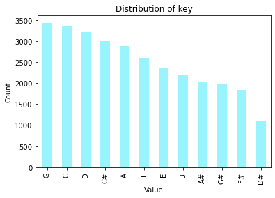

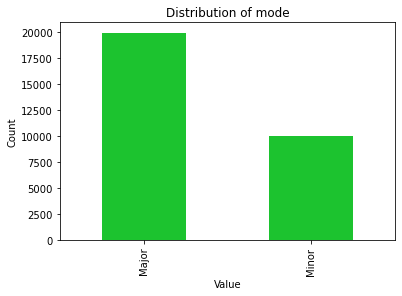

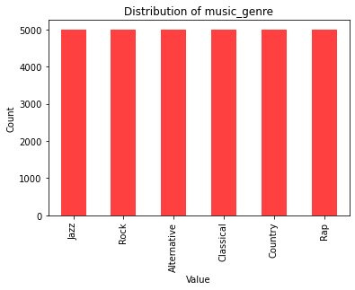

```python
for column in non_numerical_column_df:
    if column != "artist_name" and column != "track_name":
        non_numerical_column_df[column].value_counts().plot.bar(color = colors[counter % 12])
        plt.xlabel("Value")
        plt.ylabel("Count")
        plt.title("Distribution of " + column)
        plt.show()
        counter += 1
```

If you want to combine histograms and KDE plot, Seaborn has another cool way to show both histograms and KDE plots in one graph: Distribution plot which draws KDE Plot with the flexibility of turning on and off the histograms by changing the hist parameter in the function.

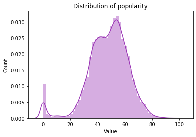

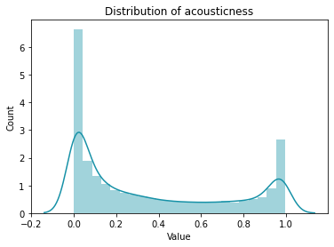

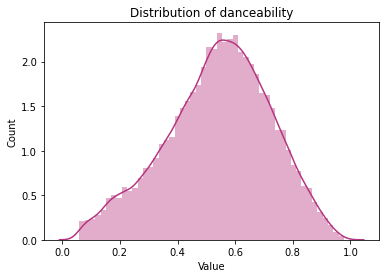

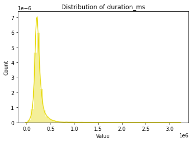

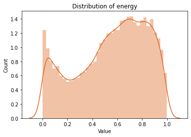

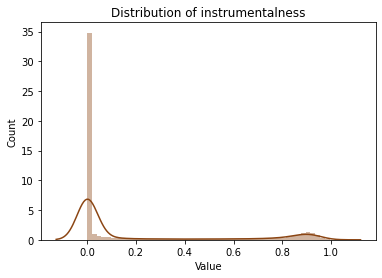

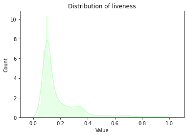

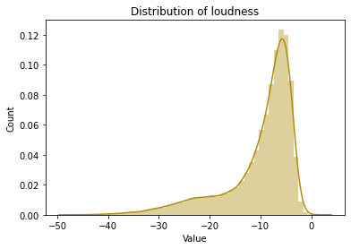

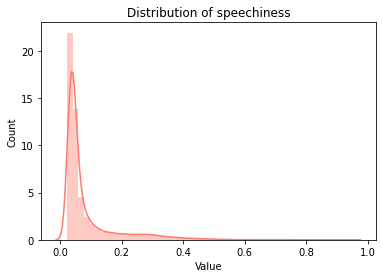

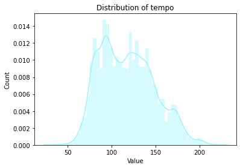

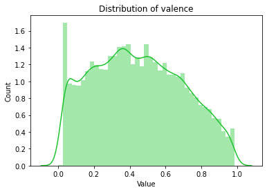

```python
for column in numerical_column_df:
    ax = sns.distplot(numerical_column_df[column], hist=True, color= colors[counter % 12])
    plt.xlabel("Value")
    plt.ylabel("Count")
    plt.title("Distribution of " + column)
    plt.show()
    counter += 1
```

## Phase 1: Preprocessing

### Question 1:

Missing values handling methods:

- **Dropping Columns:** In this approach we drop columns with missing values. This method is advised only when there are enough samples in the data set. The problem with this approach is that we lose useful data which will not give the expected results while predicting the output, but it may be effective when most data in a column is missing. Removing the data will lead to loss of information which will not give the expected results while predicting the output.
- **Replacing with Mean or Median or Mode:** In this method we fill missing values with mean/median/mode of the column. This strategy can be applied on an attribute which has numeric data. We can calculate the mean, median or mode of the attribute and replace it with the missing values. The choice to whether use mean or median depends on the domain, outliers influence mean to change a lot but they don't have much influence on median.The problem with using this approach is that we can't use it on categorical data and it may not be always effecient.
- **Predicting The Missing Values:** we can predict the nulls with the help of a machine learning algorithm; this can be done by using the attributes which do not have missing values. This method may result in better accuracy, unless a missing value is expected to have a very high variance.
- **Using Algorithms which Support Missing Values:** KNN is a machine learning algorithm which works on the principle of distance measure. This algorithm can be used when there are nulls present in the dataset. While the algorithm is applied, KNN considers the missing values by taking the majority of the K nearest values. Another algorithm which can be used here is RandomForest. This model produces a robust result because it works well on non-linear and the categorical data. It adapts to the data structure taking into consideration of the high variance or the bias, producing better results on large datasets.

#### Comparing Techniques

- Complete removal of data with missing values results in robust and highly accurate model and deleting a particular row or a column with no specific information is better, since it does not have a high weightage.But sometimes it may result in loss of information and data and works poorly if the percentage of missing values is high, compared to the whole dataset.
- Statistical approach is a better approach when the data size is small. It can prevent data loss which results in removal of the rows and columns. But, imputing the approximations add variance and bias and it works poorly compared to other multiple-imputations method.
- Imputing the missing variable is an improvement as long as the bias from the same is smaller than the omitted variable bias. Moreover, this approach yields unbiased estimates of the model parameters. But, bias also arises when an incomplete conditioning set is used for a categorical variable and considered only as a proxy for the true values.
- Using algorithms which Support missing values does not require creation of a predictive model for each attribute with missing data in the dataset. Moreover, correlation of the data is neglected. But, it is a very time consuming process and it can be critical in data mining where large databases are being extracted.

### Question 2

```python
nan_cols = ["duration_ms", "tempo"]
print(dataset_df[nan_cols].mean())

nan_cols = ["artist_name", "duration_ms", "tempo"]
print(dataset_df[nan_cols].mode())
```

```
duration_ms    246646.049722
tempo             117.559824
dtype: float64
               artist_name  duration_ms    tempo
0  Wolfgang Amadeus Mozart     180000.0  120.012
```

```python
# for column in nan_cols:
#     dataset_df.loc[:,column].fillna(dataset_df[column].mode(), inplace = True)
dataset_df.loc[:,"artist_name"].fillna("Wolfgang Amadeus Mozart", inplace = True)
dataset_df.loc[:,"duration_ms"].fillna(246646.049722, inplace = True)
dataset_df.loc[:,"tempo"].fillna(117.559824, inplace = True)

missing_values = dataset_df.isna().sum()/len(dataset_df) * 100
missing_values = pd.DataFrame({'Property': dataset_df.columns, 'Percentage of Missing Values': missing_values})
missing_values.reset_index(inplace=True, drop=True)
print(missing_values)
```

```
            Property  Percentage of Missing Values
0        artist_name                           0.0
1         track_name                           0.0
2         popularity                           0.0
3       acousticness                           0.0
4       danceability                           0.0
5        duration_ms                           0.0
6             energy                           0.0
7   instrumentalness                           0.0
8                key                           0.0
9           liveness                           0.0
10          loudness                           0.0
11              mode                           0.0
12       speechiness                           0.0
13             tempo                           0.0
14           valence                           0.0
15       music_genre                           0.0
```

### Question 3:

- **Normalizing Data:** Normalization refers to rescaling real valued numeric attributes into the range 0 and 1. Normalization change the values of numeric columns in the dataset to a common scale, without distorting differences in the ranges of values. Normalization is required only when features have different ranges.
- **Standardizing Data:** Standardization refers to shifting the distribution of each attribute to have a mean of zero and a standard deviation of one (unit variance). When we compare measurements that have different units Standardizing the features is important. Variables that are measured at different scales do not contribute equally to the analysis and might end up creating a bais.

### Question 4:

The good point of these approaches is that they get all data to the same scale, This may improve learning and may have better effect on some optimization methods. Standardizing the features around the center and 0 with a standard deviation of 1 is important when we compare measurements that have different units. Variables that are measured at different scales do not contribute equally to the analysis and might end up creating a bais. We used Standardizing for the above reasons.

```python
# # norm_column = ["popularity", "duration_ms", "loudness", "tempo"]
norm_column = list(dataset_df._get_numeric_data().columns)

# for column in norm_column:
#     ax = dataset_df[column].plot.kde()
```

```python
#standardize
for col in norm_column:
    dataset_df[col] = (dataset_df[col]-dataset_df[col].min())/dataset_df[col].std() #  (dataset_df[col].max()-dataset_df[col].min())
dataset_df
```

|  | artist_name | track_name | popularity | acousticness | danceability | duration_ms | energy | instrumentalness | key | liveness | loudness | mode | speechiness | tempo | valence | music_genre |
| --- | --- | --- | --- | --- | --- | --- | --- | --- | --- | --- | --- | --- | --- | --- | --- | --- |
| 0 | Blockhead | Cheer up, You're Not Dead Yet | 3.031835 | 0.017048 | 3.584661 | 2.532514 | 2.232119 | 0.090174 | G | 0.950687 | 5.697061 | Major | 0.170298 | 3.691555 | 2.440249 | Jazz |
| 1 | FloFilz | Corners | 2.342781 | 0.952816 | 3.683715 | 0.825770 | 1.850627 | 0.021010 | C | 0.738391 | 5.306204 | Major | 1.731898 | 1.563491 | 1.153792 | Jazz |
| 2 | Bonobo | We Could Forever | 3.514172 | 0.049697 | 3.353534 | 2.164160 | 3.182251 | 2.671809 | G | 1.653917 | 5.747249 | Minor | 0.166014 | 2.851749 | 2.556835 | Jazz |
| 3 | Nils Landgren | A Child Is Born | 2.687308 | 2.520712 | 2.335477 | 1.996439 | 0.246559 | 0.000210 | F | 0.818002 | 4.530384 | Major | 0.131740 | 1.657324 | 0.828157 | Jazz |
| 4 | Masayoshi Takanaka | Samba Pati | 2.480592 | 0.094729 | 2.274944 | 3.065087 | 2.959114 | 1.354121 | G | 1.925921 | 5.812679 | Major | 0.435920 | 2.410830 | 1.539729 | Jazz |
| ... | ... | ... | ... | ... | ... | ... | ... | ... | ... | ... | ... | ... | ... | ... | ... | ... |
| 29995 | Wolfgang Amadeus Mozart | Die Zauberflöte, K. 620: Wie stark ist nicht d... | 1.515917 | 2.501491 | 1.466002 | 3.306402 | 0.475815 | 0.000000 | G | 0.758294 | 3.818413 | Major | 0.357733 | 1.978884 | 0.828157 | Classical |
| 29996 | New York Philharmonic | Symphony No. 2 in D Major, Op. 73: II. Adagio ... | 1.791539 | 2.649768 | 0.365400 | 4.669418 | 0.731342 | 2.638411 | B | 0.599072 | 4.396359 | Major | 0.184222 | 1.648071 | 0.155581 | Classical |
| 29997 | Georges Bizet | Bizet: Carmen, WD 31, Act 1 Scene 4: No. 5, Ha... | 3.720888 | 2.679973 | 1.669613 | 2.309297 | 0.411033 | 0.000000 | D | 0.553959 | 4.273982 | Major | 0.499112 | 2.851749 | 0.928662 | Classical |
| 29998 | Edvard Grieg | Peer Gynt-Suite Nr. 1, Op. 46: I. Morning | 2.894024 | 2.704686 | 0.348891 | 2.285197 | 0.059772 | 2.750749 | E | 0.725123 | 3.361406 | Major | 0.198145 | 1.280279 | 0.141510 | Classical |
| 29999 | Johann Sebastian Bach | Suite No. 2 in B Minor, BWV 1067: VI. Menuet | 2.480592 | 2.119814 | 2.346483 | 0.553275 | 0.562190 | 2.750749 | G# | 0.871076 | 4.021895 | Minor | 0.162801 | 3.097715 | 2.488491 | Classical |

30000 rows × 16 columns

```python
# for column in norm_column:
#     ax = dataset_df[column].plot.kde()
```

### Question 5:

There are different ways for handling categirical data.

Label Encoders aren't a good option when we have no particular ordering in our categories. In these cases, we can use One Hot Encoding which takes a lot of memory since it is adding a new column for each new category. We use Ordinal Encoding because its give us better features.

```python
from sklearn.preprocessing import OrdinalEncoder
pd.options.mode.chained_assignment = None  # default='warn'
#numerical_cols = list(dataset_df._get_numeric_data().columns)
#categorical_cols = [x for x in list(dataset_df.columns) if x not in numerical_cols]
categorical_cols = ["artist_name", "key", "mode", "music_genre"] #
ord_enc = OrdinalEncoder()
dataset_df[categorical_cols] = ord_enc.fit_transform(dataset_df[categorical_cols].astype(str))
dataset_df

# for col in dataset_df:
#     if col == 'key' or col == 'mode':
#         brand_one_hot = pd.get_dummies(dataset_df[col], prefix=col)
#         dataset_df = dataset_df.drop([col], axis = 1)
#         dataset_df = pd.concat([dataset_df, brand_one_hot], axis = 1)
# dataset_df

# from sklearn.preprocessing import OneHotEncoder
# numerical_cols = list(dataset_df._get_numeric_data().columns)
# categorical_cols = [x for x in list(dataset_df.columns) if x not in numerical_cols]
# encoder = OneHotEncoder()
# onehot = encoder.fit_transform(dataset_df[categorical_cols]).toarray()
# encoder_cols = encoder.get_feature_names(categorical_cols)
# categorical_df = pd.DataFrame(onehot,columns = encoder_cols)
# categorical_df
```

|  | artist_name | track_name | popularity | acousticness | danceability | duration_ms | energy | instrumentalness | key | liveness | loudness | mode | speechiness | tempo | valence | music_genre |
| --- | --- | --- | --- | --- | --- | --- | --- | --- | --- | --- | --- | --- | --- | --- | --- | --- |
| 0 | 531.0 | Cheer up, You're Not Dead Yet | 3.031835 | 0.017048 | 3.584661 | 2.532514 | 2.232119 | 0.090174 | 10.0 | 0.950687 | 5.697061 | 0.0 | 0.170298 | 3.691555 | 2.440249 | 3.0 |
| 1 | 1511.0 | Corners | 2.342781 | 0.952816 | 3.683715 | 0.825770 | 1.850627 | 0.021010 | 3.0 | 0.738391 | 5.306204 | 0.0 | 1.731898 | 1.563491 | 1.153792 | 3.0 |
| 2 | 582.0 | We Could Forever | 3.514172 | 0.049697 | 3.353534 | 2.164160 | 3.182251 | 2.671809 | 10.0 | 1.653917 | 5.747249 | 1.0 | 0.166014 | 2.851749 | 2.556835 | 3.0 |
| 3 | 3210.0 | A Child Is Born | 2.687308 | 2.520712 | 2.335477 | 1.996439 | 0.246559 | 0.000210 | 8.0 | 0.818002 | 4.530384 | 0.0 | 0.131740 | 1.657324 | 0.828157 | 3.0 |
| 4 | 2874.0 | Samba Pati | 2.480592 | 0.094729 | 2.274944 | 3.065087 | 2.959114 | 1.354121 | 10.0 | 1.925921 | 5.812679 | 0.0 | 0.435920 | 2.410830 | 1.539729 | 3.0 |
| ... | ... | ... | ... | ... | ... | ... | ... | ... | ... | ... | ... | ... | ... | ... | ... | ... |
| 29995 | 4924.0 | Die Zauberflöte, K. 620: Wie stark ist nicht d... | 1.515917 | 2.501491 | 1.466002 | 3.306402 | 0.475815 | 0.000000 | 10.0 | 0.758294 | 3.818413 | 0.0 | 0.357733 | 1.978884 | 0.828157 | 1.0 |
| 29996 | 3176.0 | Symphony No. 2 in D Major, Op. 73: II. Adagio ... | 1.791539 | 2.649768 | 0.365400 | 4.669418 | 0.731342 | 2.638411 | 2.0 | 0.599072 | 4.396359 | 0.0 | 0.184222 | 1.648071 | 0.155581 | 1.0 |
| 29997 | 1662.0 | Bizet: Carmen, WD 31, Act 1 Scene 4: No. 5, Ha... | 3.720888 | 2.679973 | 1.669613 | 2.309297 | 0.411033 | 0.000000 | 5.0 | 0.553959 | 4.273982 | 0.0 | 0.499112 | 2.851749 | 0.928662 | 1.0 |
| 29998 | 1330.0 | Peer Gynt-Suite Nr. 1, Op. 46: I. Morning | 2.894024 | 2.704686 | 0.348891 | 2.285197 | 0.059772 | 2.750749 | 7.0 | 0.725123 | 3.361406 | 0.0 | 0.198145 | 1.280279 | 0.141510 | 1.0 |
| 29999 | 2219.0 | Suite No. 2 in B Minor, BWV 1067: VI. Menuet | 2.480592 | 2.119814 | 2.346483 | 0.553275 | 0.562190 | 2.750749 | 11.0 | 0.871076 | 4.021895 | 1.0 | 0.162801 | 3.097715 | 2.488491 | 1.0 |

30000 rows × 16 columns

### Question 6:

No, because it is not a general feature and it makes our model overfit.

No, in this particular issue there is no other way but to delete.

```python
dataset_df = dataset_df.drop(columns=["artist_name"], axis = 1)
```

### Question 7:

```python
from sklearn.feature_selection import mutual_info_classif
features = ["track_name", "music_genre"] # "artist_name",
y = dataset_df['music_genre']
X = dataset_df.copy()
X = X.drop(columns=features, axis = 1)
mir = mutual_info_classif(X, y)
mir = pd.Series(mir)
mir.index = X.columns
mir
```

```
popularity          0.511619
acousticness        0.356970
danceability        0.276094
duration_ms         0.104248
energy              0.327380
instrumentalness    0.296252
key                 0.017123
liveness            0.013765
loudness            0.345331
mode                0.037935
speechiness         0.216152
tempo               0.091570
valence             0.141467
dtype: float64
```

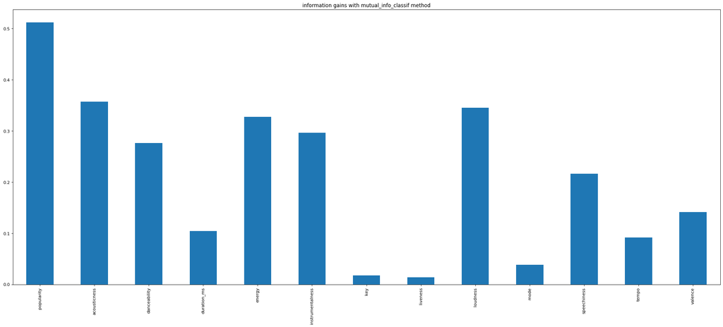

```python
plt.figure(figsize=(30,12), dpi= 80, facecolor='w', edgecolor='k')
mir.plot.bar()
plt.title('information gains with mutual_info_classif method')
plt.show()
```

if information gain (the values in the bar chart below) is high it means that the corresponding feature can provide more information than the others meaning that it'll help the training procedure more so it's a good idea to keep that feature in the dataset and use it's values in the training. This plot shows that the columns genres are giving us more useful info about the type of each row. We can simply eliminate the other columns since they don't have much gain.

[figure not shown]

```python
from sklearn.feature_selection import mutual_info_classif

information_gains = dict(zip(dataset_df.drop(columns=features).columns, mutual_info_classif(dataset_df.drop(columns=features), dataset_df["music_genre"])))
lists = sorted(information_gains.items())
x_, y_ = zip(*lists)
fig=plt.figure(figsize=(32,12), dpi= 80, facecolor='w', edgecolor='k')
plt.plot(x_, y_)
plt.title('information gains with mutual_info_classif method')
plt.xticks(x_, information_gains.keys(), rotation='vertical')
plt.show()
```

Mutual information is a quantity that measures how much one random variables tells about another. Mutual information can be thought of as the reduction in uncertainty about one random variable given knowledge of another. High mutual information indicates a large reduction in uncertainty; low mutual information indicates a small reduction; and zero mutual information between two random variables means the variables are independent. For calculating the information gain of features in this project the mutual_info_classif function from sklearn.feature_selection was used. The function returns an estimate for mutual information for a discrete target variable Mutual information between two random variables is a non-negative value, which measures the dependency between the variables. It is equal to zero if and only if two random variables are independent, and higher values mean higher dependency.

### Question 8:

Feature selection is meant to choose the most effective features from data. As we mentioned earlier we can use the the correlation between features and target to determine the most numerical features. For the categorical features we can use the chi-square approach to check independent features from target and remove them. Dimensionality reduction may create new features from current features to get more accuraccy.

An alternative approach could be to remove categorical variables from the dataset. While removing features is always an option, it may not be the best way to deal with categorical variables as we will lose potentially important information.

```python
dataset_df.corr()
```

|  | popularity | acousticness | danceability | duration_ms | energy | instrumentalness | key | liveness | loudness | mode | speechiness | tempo | valence | music_genre |
| --- | --- | --- | --- | --- | --- | --- | --- | --- | --- | --- | --- | --- | --- | --- |
| popularity | 1.000000 | -0.492042 | 0.389418 | -0.166655 | 0.451701 | -0.436152 | -0.008717 | -0.004752 | 0.517701 | 0.016224 | 0.180995 | 0.132036 | 0.218227 | 0.455753 |
| acousticness | -0.492042 | 1.000000 | -0.418800 | 0.152553 | -0.828621 | 0.503045 | 0.002657 | -0.106425 | -0.764769 | -0.011329 | -0.161871 | -0.237866 | -0.352605 | -0.233467 |
| danceability | 0.389418 | -0.418800 | 1.000000 | -0.265493 | 0.361624 | -0.368382 | -0.013506 | -0.011083 | 0.480630 | 0.053878 | 0.287133 | 0.027211 | 0.520106 | 0.313659 |
| duration_ms | -0.166655 | 0.152553 | -0.265493 | 1.000000 | -0.160673 | 0.217928 | -0.006151 | -0.004920 | -0.190276 | 0.015769 | -0.109565 | -0.059967 | -0.227340 | -0.084784 |
| energy | 0.451701 | -0.828621 | 0.361624 | -0.160673 | 1.000000 | -0.503935 | -0.000817 | 0.171249 | 0.854594 | 0.003604 | 0.156105 | 0.260714 | 0.474142 | 0.201045 |
| instrumentalness | -0.436152 | 0.503045 | -0.368382 | 0.217928 | -0.503935 | 1.000000 | 0.005025 | -0.123230 | -0.610806 | 0.067548 | -0.178464 | -0.180273 | -0.287506 | -0.215809 |
| key | -0.008717 | 0.002657 | -0.013506 | -0.006151 | -0.000817 | 0.005025 | 1.000000 | -0.002240 | -0.005377 | -0.060108 | -0.008885 | -0.006068 | 0.002751 | -0.016136 |
| liveness | -0.004752 | -0.106425 | -0.011083 | -0.004920 | 0.171249 | -0.123230 | -0.002240 | 1.000000 | 0.123813 | -0.013245 | 0.120935 | 0.033908 | 0.063450 | 0.012663 |
| loudness | 0.517701 | -0.764769 | 0.480630 | -0.190276 | 0.854594 | -0.610806 | -0.005377 | 0.123813 | 1.000000 | -0.005369 | 0.157803 | 0.246364 | 0.416076 | 0.261961 |
| mode | 0.016224 | -0.011329 | 0.053878 | 0.015769 | 0.003604 | 0.067548 | -0.060108 | -0.013245 | -0.005369 | 1.000000 | 0.103683 | -0.024376 | -0.014055 | 0.015596 |
| speechiness | 0.180995 | -0.161871 | 0.287133 | -0.109565 | 0.156105 | -0.178464 | -0.008885 | 0.120935 | 0.157803 | 0.103683 | 1.000000 | 0.056732 | 0.086755 | 0.132178 |
| tempo | 0.132036 | -0.237866 | 0.027211 | -0.059967 | 0.260714 | -0.180273 | -0.006068 | 0.033908 | 0.246364 | -0.024376 | 0.056732 | 1.000000 | 0.132896 | 0.057941 |
| valence | 0.218227 | -0.352605 | 0.520106 | -0.227340 | 0.474142 | -0.287506 | 0.002751 | 0.063450 | 0.416076 | -0.014055 | 0.086755 | 0.132896 | 1.000000 | 0.209936 |
| music_genre | 0.455753 | -0.233467 | 0.313659 | -0.084784 | 0.201045 | -0.215809 | -0.016136 | 0.012663 | 0.261961 | 0.015596 | 0.132178 | 0.057941 | 0.209936 | 1.000000 |

```python
# fig, ax = plt.subplots(figsize=(20,12))
# sns.heatmap(dataset_df.corr(), center=0, cmap='RdPu')
# ax.set_title('Multi-Collinearity of Music Attributes')
```

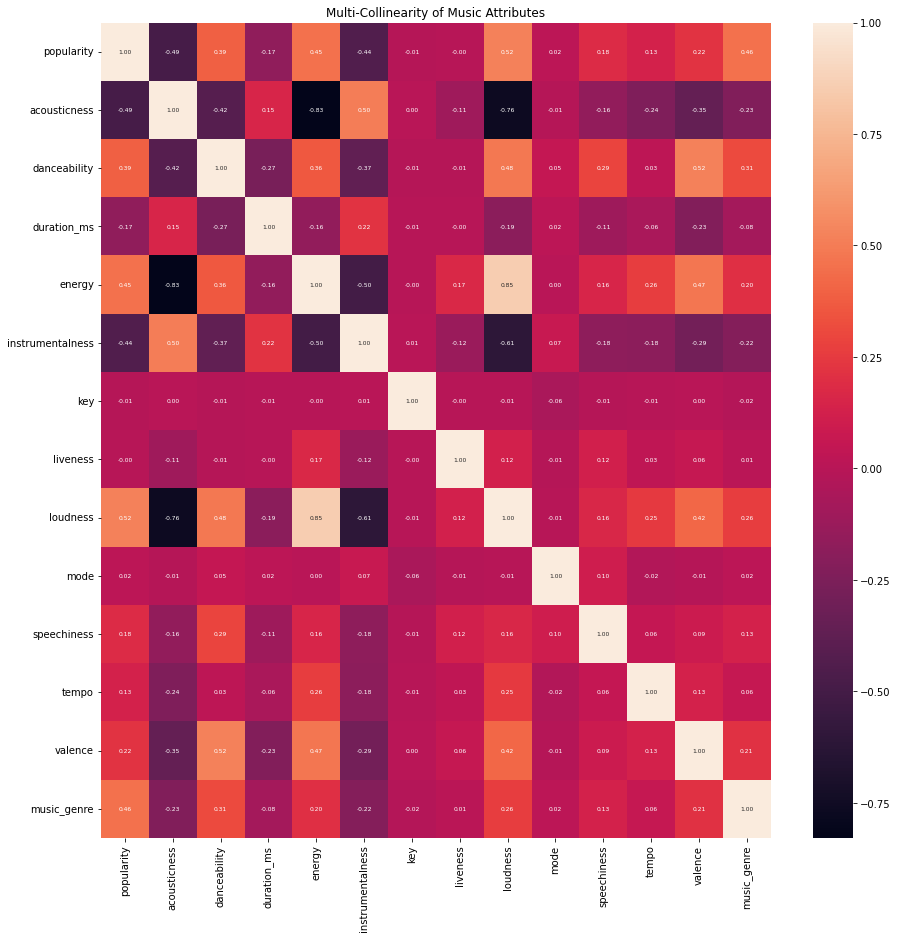

```python
corr = dataset_df.corr()
plt.figure(figsize=(15, 15))
sns.heatmap(corr, annot=True, fmt=".2f", annot_kws={"fontsize":6})
plt.title("Multi-Collinearity of Music Attributes")
plt.show()
```

```python
# from heatmap import corrplot

# plt.figure(figsize=(10, 10))
# corrplot(dataset_df.corr(), size_scale=200);
```

```python
low_gain_columns = ["key" ,"liveness"]
# low_gain_columns = ["artist_name", "duration_ms", "key" ,"liveness", "mode", "speechiness", "tempo", "valence"]
# low_gain_columns = ["danceability", "instrumentalness", "key" ,"loudness", "speechiness", "tempo", "valence"]
dataset_df = dataset_df.drop(columns=low_gain_columns)

# high_gain_columns = ["popularity", "danceability", "energy", "loudness", "valence", 'music_genre']
# dataset_df = dataset_df[high_gain_columns]
# features = ["music_genre"]

dataset_df
```

|  | track_name | popularity | acousticness | danceability | duration_ms | energy | instrumentalness | loudness | mode | speechiness | tempo | valence | music_genre |
| --- | --- | --- | --- | --- | --- | --- | --- | --- | --- | --- | --- | --- | --- |
| 0 | Cheer up, You're Not Dead Yet | 3.031835 | 0.017048 | 3.584661 | 2.532514 | 2.232119 | 0.090174 | 5.697061 | 0.0 | 0.170298 | 3.691555 | 2.440249 | 3.0 |
| 1 | Corners | 2.342781 | 0.952816 | 3.683715 | 0.825770 | 1.850627 | 0.021010 | 5.306204 | 0.0 | 1.731898 | 1.563491 | 1.153792 | 3.0 |
| 2 | We Could Forever | 3.514172 | 0.049697 | 3.353534 | 2.164160 | 3.182251 | 2.671809 | 5.747249 | 1.0 | 0.166014 | 2.851749 | 2.556835 | 3.0 |
| 3 | A Child Is Born | 2.687308 | 2.520712 | 2.335477 | 1.996439 | 0.246559 | 0.000210 | 4.530384 | 0.0 | 0.131740 | 1.657324 | 0.828157 | 3.0 |
| 4 | Samba Pati | 2.480592 | 0.094729 | 2.274944 | 3.065087 | 2.959114 | 1.354121 | 5.812679 | 0.0 | 0.435920 | 2.410830 | 1.539729 | 3.0 |
| ... | ... | ... | ... | ... | ... | ... | ... | ... | ... | ... | ... | ... | ... |
| 29995 | Die Zauberflöte, K. 620: Wie stark ist nicht d... | 1.515917 | 2.501491 | 1.466002 | 3.306402 | 0.475815 | 0.000000 | 3.818413 | 0.0 | 0.357733 | 1.978884 | 0.828157 | 1.0 |
| 29996 | Symphony No. 2 in D Major, Op. 73: II. Adagio ... | 1.791539 | 2.649768 | 0.365400 | 4.669418 | 0.731342 | 2.638411 | 4.396359 | 0.0 | 0.184222 | 1.648071 | 0.155581 | 1.0 |
| 29997 | Bizet: Carmen, WD 31, Act 1 Scene 4: No. 5, Ha... | 3.720888 | 2.679973 | 1.669613 | 2.309297 | 0.411033 | 0.000000 | 4.273982 | 0.0 | 0.499112 | 2.851749 | 0.928662 | 1.0 |
| 29998 | Peer Gynt-Suite Nr. 1, Op. 46: I. Morning | 2.894024 | 2.704686 | 0.348891 | 2.285197 | 0.059772 | 2.750749 | 3.361406 | 0.0 | 0.198145 | 1.280279 | 0.141510 | 1.0 |
| 29999 | Suite No. 2 in B Minor, BWV 1067: VI. Menuet | 2.480592 | 2.119814 | 2.346483 | 0.553275 | 0.562190 | 2.750749 | 4.021895 | 1.0 | 0.162801 | 3.097715 | 2.488491 | 1.0 |

30000 rows × 13 columns

## Phase 2: Model Training, Evaluation and Hyper Parameter Tuning

### Question 1:

The `P` ratio depends on lots of metrics but two important metrics to mention are the number of rows in our data and our data itself. Assume that we have extremely small data in this situations small p may effect our learning accuracy. In larger datasets we can do the split with more confidence. After reading some documents online I came to the understanding that 10% to 30% is a good percentage for test size and by experimenting different values I decided to use the value 20%.

Another important note to mention is randomness. We must shuffle our data so there is no learning from the sequence of data itself. `random_state` is for getting the same set of data each time so that we don't get different results, meaning it won't give us random data each time. `random_state` is like the seed that we set for random.

The `stratify` parameter makes a split so that the proportion of values in the sample produced will be the same as the proportion of values provided to parameter `stratify`. For example, if variable `y` is a binary categorical variable with values `0` and 1 and there are 25% of zeros and 75% of ones, `stratify=y` will make sure that your random split has 25% of `0`'s and 75% of `1`'s.

### Question 2:

```python
from sklearn.preprocessing import StandardScaler
from sklearn.model_selection import train_test_split

Y = dataset_df['music_genre']
X = dataset_df.drop(columns=features, axis = 1)
X_train, X_test, Y_train, Y_test = train_test_split(X , Y , test_size = 0.20 , random_state = 42)
scaler = StandardScaler()
scaler.fit(X_train)
X_train = scaler.transform(X_train)
X_test = scaler.transform(X_test)
```

### Question 3:

```
Best neighbors index: 19
Best possible accuracy: 65.5
```

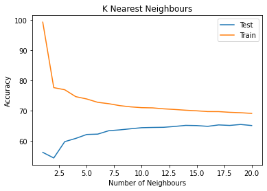

```python
from sklearn.neighbors import KNeighborsClassifier
from sklearn import metrics
from sklearn.metrics import classification_report, confusion_matrix

best_n_neighbors = 0

def KNN_tuning():
    train_accuracy = []
    test_accuracy = []
    max_accuracy = 0
    global best_n_neighbors
    for i in list(range(1,21)):
        KNN = KNeighborsClassifier(n_neighbors = i)
        KNN = KNN.fit(X_train, Y_train)
        test_predict = KNN.predict(X_test)
        train_predict = KNN.predict(X_train)
        train_accuracy.append(metrics.accuracy_score(Y_train, train_predict)* 100)
        test_accuracy.append(metrics.accuracy_score(Y_test, test_predict)* 100)
        if (metrics.accuracy_score(Y_test, test_predict)* 100) > max_accuracy:
            max_accuracy = metrics.accuracy_score(Y_test, test_predict) * 100
            best_n_neighbors = i

    print("Best neighbors index:", best_n_neighbors)
    print("Best possible accuracy: " + str(max_accuracy))
    plt.plot(list(range(1, 21)),test_accuracy, label='Test')
    plt.plot(list(range(1, 21)), train_accuracy, label='Train')
    plt.ylabel('Accuracy')
    plt.xlabel('Number of Neighbours')
    plt.title('K Nearest Neighbours')
    plt.legend()
    plt.show()

KNN_tuning()
```

- **Overfitting** usually takes place when a model has an excessively complex structure and learns both the existing relations among data and noise. Such models often have bad generalization capabilities. Although they work well with training data, they usually yield poor performance with unseen (test) data.

### Question 4:

```python
from sklearn import tree
from sklearn.metrics import confusion_matrix , ConfusionMatrixDisplay
from sklearn.metrics import accuracy_score
from sklearn import metrics
from sklearn.metrics import plot_confusion_matrix
from sklearn.svm import SVC
from sklearn.tree import DecisionTreeClassifier

def decision_tree_method(best_depth , min_leaf , X_train , Y_train , X_test , Y_test):
    print("best_depth =", best_depth, "and min_samples_leaf =", min_leaf)
    reg = tree.DecisionTreeClassifier(max_depth = best_depth , min_samples_leaf = min_leaf)
    reg = reg.fit(X_train, Y_train)
    test_predict = reg.predict(X_test)
    train_predict = reg.predict(X_train)
    test_cm = confusion_matrix(Y_test , np.round(abs(test_predict)))
    print("confusion_matrix for test dataset:")
    clf = SVC(random_state=0)
    clf.fit(X_test, Y_test)
    disp = ConfusionMatrixDisplay(confusion_matrix=test_cm, display_labels=clf.classes_)
    disp.plot()
    plt.show()
    train_cm = confusion_matrix(Y_train , np.round(abs(train_predict)))
    print("confusion_matrix for train dataset:")
    clf = SVC(random_state=0)
    clf.fit(X_train, Y_train)
    disp = ConfusionMatrixDisplay(confusion_matrix=train_cm, display_labels=clf.classes_)
    disp.plot()
    plt.show()
    print("-------------------------------------------------------------------------")
```

```python
# decision_tree_method(6 , 12 , X_train , Y_train , X_test , Y_test)
```

```python
# decision_tree_method(1 , 2 , X_train , Y_train , X_test , Y_test)
# decision_tree_method(3 , 2 , X_train , Y_train , X_test , Y_test)
# decision_tree_method(5 , 2 , X_train , Y_train , X_test , Y_test)
# decision_tree_method(7 , 2 , X_train , Y_train , X_test , Y_test)
# decision_tree_method(10 , 2 , X_train , Y_train , X_test , Y_test)
```

```python
# decision_tree_method(5 , 5 , X_train , Y_train , X_test , Y_test)
# decision_tree_method(5 , 35 , X_train , Y_train , X_test , Y_test)
# decision_tree_method(5 , 135 , X_train , Y_train , X_test , Y_test)
```

```
test_size = 0.20

min_samples_leaf = 1
```

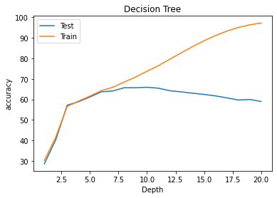

```
min_samples_leaf = 2
```

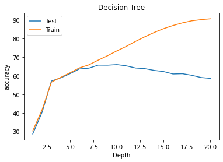

```
min_samples_leaf = 3
```

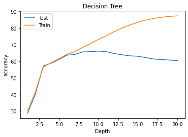

```
min_samples_leaf = 4
```

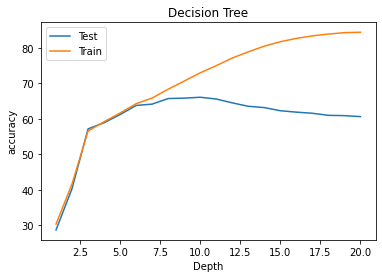

```
min_samples_leaf = 5
```

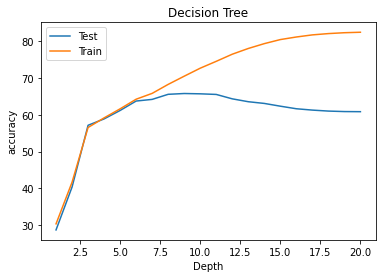

```
min_samples_leaf = 6
```

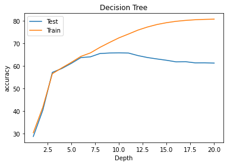

```
min_samples_leaf = 7
```

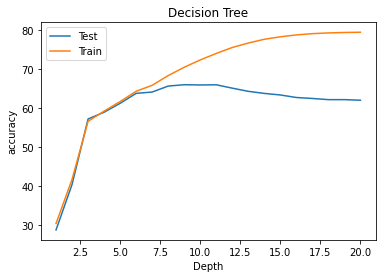

```
min_samples_leaf = 8
```

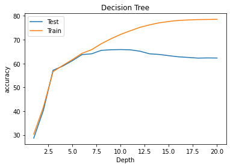

```
min_samples_leaf = 9
```

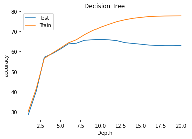

```
min_samples_leaf = 10
```

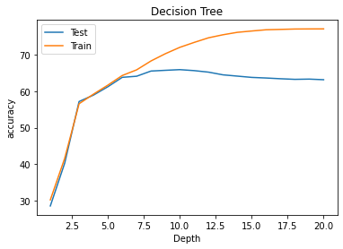

```
min_samples_leaf = 11
```

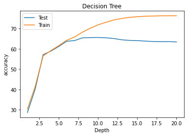

```
min_samples_leaf = 12
```

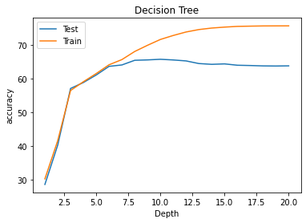

```
min_samples_leaf = 13
```

[8 more figures not shown]

```
Best possible max_depth: 10
Best possible min_samples_leaf: 3
Best possible accuracy: 66.13333333333333
```

```python
best_DT_max_depth = -1
best_DT_min_samples_leaf = -1

def decision_tree_tuning(X_train , Y_train , X_test , Y_test):
    train_acc = []
    test_acc = []
    max_acc = float("-inf")
    global best_DT_max_depth
    global best_DT_min_samples_leaf
    for j in range(1, 21):
        print("min_samples_leaf =", j)
        for i in list(range(1 , 21)):
            DT = DecisionTreeClassifier(max_depth = i , min_samples_leaf = j)
            DT = DT.fit(X_train, Y_train)
            test_predict = DT.predict(X_test)
            train_predict = DT.predict(X_train)
            train_acc.append(float((accuracy_score(Y_train, np.round(abs(train_predict)))) * 100))
            test_acc.append(float((accuracy_score(Y_test, np.round(abs(test_predict)))) * 100))
            if(float((accuracy_score(Y_test, np.round(abs(test_predict)))) * 100) > max_acc):
                max_acc = float((accuracy_score(Y_test, np.round(abs(test_predict)))) * 100)
                best_DT_max_depth = i
                best_DT_min_samples_leaf = j
        plt.plot(list(range(1, 21)), test_acc, label='Test')
        plt.plot(list(range(1, 21)), train_acc, label='Train')
        plt.ylabel('accuracy')
        plt.xlabel('Depth')
        plt.title('Decision Tree')
        plt.legend()
        plt.show()
        test_acc.clear()
        train_acc.clear()

    print("Best possible max_depth: " + str(best_DT_max_depth))
    print("Best possible min_samples_leaf: " + str(best_DT_min_samples_leaf))
    print("Best possible accuracy: " + str(max_acc))

print("test_size = 0.20\n")
decision_tree_tuning(X_train , Y_train , X_test , Y_test)
```

```
test_size = 0.20
```

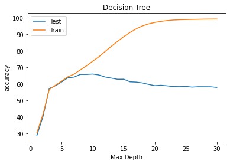

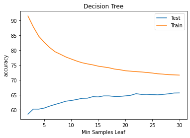

```
Best possible max_depth: 10
Best possible min_samples_leaf: 30
Best possible accuracy: 65.61666666666667
```

```python
def decision_tree_tuning(X_train , Y_train , X_test , Y_test):
    train_acc = []
    test_acc = []
    max_acc = float("-inf")
    global best_DT_max_depth
    global best_DT_min_samples_leaf

    for i in list(range(1 , 31)):
        DT = DecisionTreeClassifier(max_depth = i)
        DT = DT.fit(X_train, Y_train)
        test_predict = DT.predict(X_test)
        train_predict = DT.predict(X_train)
        train_acc.append(float((accuracy_score(Y_train, np.round(abs(train_predict)))) * 100))
        test_acc.append(float((accuracy_score(Y_test, np.round(abs(test_predict)))) * 100))
        if(float((accuracy_score(Y_test, np.round(abs(test_predict)))) * 100) > max_acc):
            max_acc = float((accuracy_score(Y_test, np.round(abs(test_predict)))) * 100)
            best_DT_max_depth = i
    plt.plot(list(range(1, 31)), test_acc, label='Test')
    plt.plot(list(range(1, 31)), train_acc, label='Train')
    plt.ylabel('accuracy')
    plt.xlabel('Max Depth')
    plt.title('Decision Tree')
    plt.legend()
    plt.show()
    test_acc.clear()
    train_acc.clear()
    max_acc = float("-inf")

    for i in list(range(2 , 31)):
        DT = DecisionTreeClassifier(min_samples_leaf = i)
        DT = DT.fit(X_train, Y_train)
        test_predict = DT.predict(X_test)
        train_predict = DT.predict(X_train)
        train_acc.append(float((accuracy_score(Y_train, np.round(abs(train_predict)))) * 100))
        test_acc.append(float((accuracy_score(Y_test, np.round(abs(test_predict)))) * 100))
        if(float((accuracy_score(Y_test, np.round(abs(test_predict)))) * 100) > max_acc):
            max_acc = float((accuracy_score(Y_test, np.round(abs(test_predict)))) * 100)
            best_DT_min_samples_leaf = i
    plt.plot(list(range(2, 31)), test_acc, label='Test')
    plt.plot(list(range(2, 31)), train_acc, label='Train')
    plt.ylabel('accuracy')
    plt.xlabel('Min Samples Leaf')
    plt.title('Decision Tree')
    plt.legend()
    plt.show()
    test_acc.clear()
    train_acc.clear()

    print("Best possible max_depth: " + str(best_DT_max_depth))
    print("Best possible min_samples_leaf: " + str(best_DT_min_samples_leaf))
    print("Best possible accuracy: " + str(max_acc))

print("test_size = 0.20\n")
decision_tree_tuning(X_train , Y_train , X_test , Y_test)
```

- **max_depth** is maximum depth of the tree if we don't assign a value to it then nodes are expanded until all leaves are pure or until all leaves contain less than min_samples_split samples. It's for knowing until what point we should continue to produce nodes. The theoretical maximum depth a decision tree can achieve is one less than the number of training samples, but no algorithm will let you reach this point for obvious reasons, one big reason being overfitting.
- **min_samples_leaf** The minimum number of samples required to be at a leaf node. A split point at any depth will only be considered if it leaves at least `min_samples_leaf` training samples in each of the left and right branches. This may have the effect of smoothing the model, especially in regression.

If we use a large `max_depth` value it'll make the model more complex meaning that there's higher chance of overfitting and will make the training process take a long time but if we use a small `max_depth` value it'll make the model simpler and will give us the result quickly meaning that there's higher chance of underfitting and here's the age old tradeoff between simplicity and consistency we have to check which value generates the best result for our model.

### Question 5:

- **Underfitting**: A statistical model or a machine learning algorithm is said to have underfitting when it cannot capture the underlying trend of the data. Underfitting destroys the accuracy of our machine learning model. Its occurrence simply means that our model or the algorithm does not fit the data well enough. It usually happens when we have less data to build an accurate model and also when we try to build a linear model with a non-linear data. In such cases the rules of the machine learning model are too easy and flexible to be applied on such minimal data and therefore the model will probably make a lot of wrong predictions. Underfitting can be avoided by using more data and also reducing the features by feature selection.
- **Overfitting**: A statistical model is said to be overfitted, when we train it with a lot of data. When a model gets trained with so much of data, it starts learning from the noise and inaccurate data entries in our data set. Then the model does not categorize the data correctly, because of too many details and noise. The causes of overfitting are the non-parametric and non-linear methods because these types of machine learning algorithms have more freedom in building the model based on the dataset and therefore they can really build unrealistic models. A solution to avoid overfitting is using a linear algorithm if we have linear data or using the parameters like the maximal depth if we are using decision trees.

all 2 trained models, perform acceptable on both training data an validation data so the model is not over fitted. by changing training data order the model fits differently so it is not under fitted.

### Question 6:

- **Recall** score is used to measure the model performance in terms of measuring the count of true positives in a correct manner out of all the actual positive values.

$${Recall = \frac{Correct Detected Class}{Total Class}}$$

- **Precision** score is used to measure the model performance in measuring the count of true positives in the correct manner out of all positive predictions made.

$${Precision = \frac{Correct Detected Class}{All Detected Class (Including Wrong Ones)}}$$

- **Accuracy** score is used to measure the model performance in terms of measuring the ratio of sum of true positive and true negatives out of all the predictions made.

$${Accuracy = \frac{Correct Detected}{Total}}$$

- **F1-score** is harmonic mean of precision and recall score and is used as a metrics in the scenarios where choosing either of precision or recall score can result in compromise in terms of model giving high false positives and false negatives respectively.

$${F1 = 2\times \frac{Precision \times Recall}{Precision \div Recall}}$$

```python
print("n_neighbors =", best_n_neighbors)
KNN = KNeighborsClassifier(n_neighbors = best_n_neighbors)
KNN = KNN.fit(X_train, Y_train)
test_predict = KNN.predict(X_test)
train_predict = KNN.predict(X_train)
print("\nKNN best test accuracy:",metrics.accuracy_score(Y_test, test_predict))
print("KNN classification report : \n", classification_report(Y_test, test_predict))
print("\nKNN best train accuracy:",metrics.accuracy_score(Y_train, train_predict))
print("KNN classification report : \n", classification_report(Y_train, train_predict))

print("\n-------------------------------------------------------------------------")

print("max_depth =", best_DT_max_depth, "and min_samples_leaf =", best_DT_min_samples_leaf)
DT = tree.DecisionTreeClassifier(max_depth = best_DT_max_depth , min_samples_leaf = best_DT_min_samples_leaf)
DT = DT.fit(X_train, Y_train)
test_predict = DT.predict(X_test)
train_predict = DT.predict(X_train)
print("\nDecision Tree best test accuracy:", accuracy_score(Y_test, np.round(abs(test_predict))))
print("Decision Tree classification report : \n", classification_report(Y_test, np.round(abs(test_predict))))
print("\nDecision Tree best train accuracy:", accuracy_score(Y_train, np.round(abs(train_predict))))
print("Decision Tree classification report : \n", classification_report(Y_train, np.round(abs(train_predict))))
```

```
n_neighbors = 19

KNN best test accuracy: 0.655
KNN classification report :
               precision    recall  f1-score   support

         0.0       0.48      0.38      0.42      1024
         1.0       0.90      0.88      0.89       969
         2.0       0.57      0.68      0.62      1046
         3.0       0.71      0.64      0.67       978
         4.0       0.70      0.79      0.74       950
         5.0       0.58      0.58      0.58      1033

    accuracy                           0.66      6000
   macro avg       0.66      0.66      0.65      6000
weighted avg       0.65      0.66      0.65      6000


KNN best train accuracy: 0.69375
KNN classification report :
               precision    recall  f1-score   support

         0.0       0.56      0.48      0.52      3976
         1.0       0.89      0.88      0.89      4031
         2.0       0.62      0.69      0.65      3954
         3.0       0.74      0.67      0.70      4022
         4.0       0.75      0.79      0.77      4050
         5.0       0.60      0.65      0.62      3967

    accuracy                           0.69     24000
   macro avg       0.69      0.69      0.69     24000
weighted avg       0.69      0.69      0.69     24000


-------------------------------------------------------------------------
max_depth = 10 and min_samples_leaf = 30

Decision Tree best test accuracy: 0.657
Decision Tree classification report :
               precision    recall  f1-score   support
```

[output cut: 12 more lines]

```

Decision Tree best train accuracy: 0.7040416666666667
Decision Tree classification report :
               precision    recall  f1-score   support

         0.0       0.59      0.47      0.52      3976
         1.0       0.91      0.88      0.89      4031
         2.0       0.66      0.65      0.65      3954
         3.0       0.73      0.71      0.72      4022
         4.0       0.77      0.80      0.78      4050
         5.0       0.58      0.72      0.64      3967

    accuracy                           0.70     24000
   macro avg       0.71      0.70      0.70     24000
weighted avg       0.71      0.70      0.70     24000
```

### Question 7:

1. Filling NaN values: This is the most common method of handling missing values. This is a process whereby missing values are replaced with a test statistic like mean, median or mode of the particular feature the missing value belongs to. One can also specify a forward-fill or back-fill to propagate the next values backward or previous value forward.
2. Label Encoding: This is a crucial part of modeling. Without it, we either should **ignore those columns** or **use one-hot** instead. Ignoring would result in a seroius loss of data that would increase error margin(by at least 20 percent!). Using one-hot has it's own problems. one-hotting all categorical columns would increase the count of coulmns to more than 3000. This might result in providing too much data that might not be useful or even decieving.
3. Dropping low gain columns: We removed the columns that have a low gain with our target column because these columns can not help us much in forecasting.
4. One-hot columns: There is an option to delete those catagorical columns that can not be label encoded. By using this method, some results in across all two models will improve will some others will be weakend. On average, there is more loss that gain here so it is better to one-hot encode them and use them for prediction.

## Phase 3: Ensemble Methods

Random Forest is one of the most popular and most powerful machine learning algorithms. It is a type of ensemble machine learning algorithm called Bootstrap Aggregation or bagging.

### Question 1:

```python
from sklearn.ensemble import RandomForestRegressor
from sklearn.ensemble import RandomForestClassifier
from sklearn.metrics import plot_confusion_matrix
from sklearn.svm import SVC
from sklearn.metrics import ConfusionMatrixDisplay

def random_forest_method(best_depth ,min_leaf , X_train , Y_train , X_test , Y_test, _n_estimators, _max_samples, _max_features):
    print("best_depth =", best_depth, "and min_samples_leaf =", min_leaf, "and n_estimators =", _n_estimators, "and max_samples =", _max_samples, "and max_features =", _max_features )
    reg = RandomForestClassifier(bootstrap = True, max_depth = best_depth , n_estimators = _n_estimators , max_samples = _max_samples, max_features = _max_features , min_samples_leaf = min_leaf)
    reg = reg.fit(X_train, Y_train)
    test_predict = reg.predict(X_test)
    train_predict = reg.predict(X_train)
    test_cm = confusion_matrix(Y_test , np.round(abs(test_predict)))
    print("\nconfusion_matrix for test:")
    clf = SVC(random_state=0)
    clf.fit(X_test, Y_test)
    disp = ConfusionMatrixDisplay(confusion_matrix=test_cm, display_labels=clf.classes_)
    disp.plot()
    plt.show()
    train_cm = confusion_matrix(Y_train , np.round(abs(train_predict)))
    print("confusion_matrix for train:")
    clf = SVC(random_state=0)
    clf.fit(X_train, Y_train)
    disp = ConfusionMatrixDisplay(confusion_matrix=train_cm, display_labels=clf.classes_)
    disp.plot()
    plt.show()
    print("-----------------------------------------------------------------------")
```

```python
# random_forest_method(7, 10, X_train , Y_train , X_test , Y_test, 200, 5000, 0.4)
# random_forest_method(6, 10, X_train , Y_train , X_test , Y_test, 20, 5000, 0.4)
# random_forest_method(12, 10, X_train , Y_train , X_test , Y_test, 20, 5000, 0.4)
# random_forest_method(12, 10, X_train , Y_train , X_test , Y_test, 200, 5000, 0.4)
```

```
test_size = 0.20

min_samples_leaf = 2 and n_estimators = 10
```

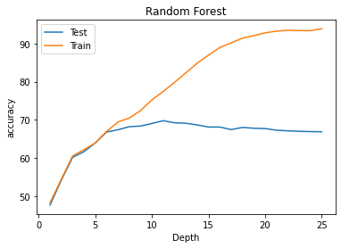

```
min_samples_leaf = 5 and n_estimators = 10
```

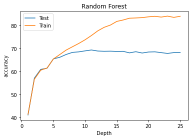

```
min_samples_leaf = 8 and n_estimators = 10
```

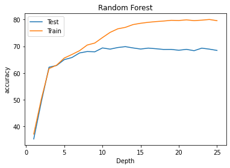

```
min_samples_leaf = 10 and n_estimators = 10
```

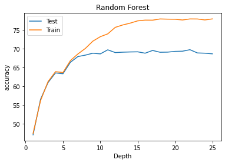

```
min_samples_leaf = 13 and n_estimators = 10
```

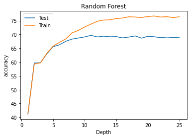

```
min_samples_leaf = 2 and n_estimators = 20
```

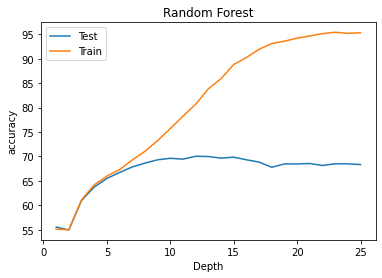

```
min_samples_leaf = 5 and n_estimators = 20
```

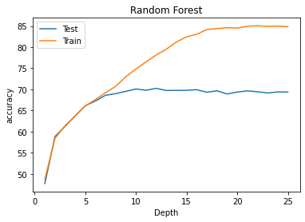

```
min_samples_leaf = 8 and n_estimators = 20
```

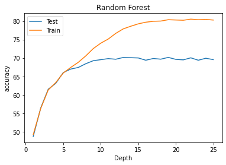

```
min_samples_leaf = 10 and n_estimators = 20
```

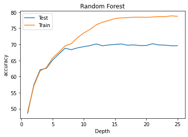

```
min_samples_leaf = 13 and n_estimators = 20
```

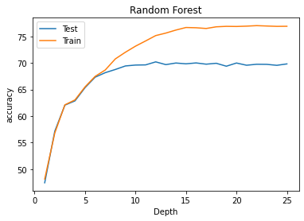

```
min_samples_leaf = 2 and n_estimators = 30
```

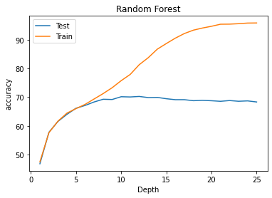

```
min_samples_leaf = 5 and n_estimators = 30
```

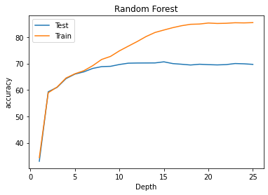

```
min_samples_leaf = 8 and n_estimators = 30
```

[3 more figures not shown]

```
Best possible max_depth: 15
Best possible min_samples_leaf: 5
Best possible n_estimators: 30
Best possible accuracy: 70.65
```

```python
best_RF_max_depth = -1
best_RF_min_samples_leaf = -1
best_RF_n_estimators = -1

def random_forest_tuning(X_train , Y_train , X_test , Y_test):
    train_acc = []
    test_acc = []
    global best_RF_max_depth
    global best_RF_min_samples_leaf
    global best_RF_n_estimators
    max_acc = float("-inf")
    l = [2, 5, 8, 10, 13]
    ne = [10, 20, 30]
    for k in ne:
        for j in l:
            print("min_samples_leaf =", j, "and n_estimators =", k )
            for i in list(range(1 , 26)):
                RF = RandomForestClassifier(max_depth = i, min_samples_leaf = j , n_estimators = k)
                RF = RF.fit(X_train, Y_train)
                test_predict = RF.predict(X_test)
                train_predict = RF.predict(X_train)
                train_acc.append(float((accuracy_score(Y_train, np.round(abs(train_predict)))) * 100))
                test_acc.append(float((accuracy_score(Y_test, np.round(abs(test_predict)))) * 100))
                if(float((accuracy_score(Y_test, np.round(abs(test_predict)))) * 100) > max_acc):
                    max_acc = float((accuracy_score(Y_test, np.round(abs(test_predict)))) * 100)
                    best_RF_max_depth = i
                    best_RF_min_samples_leaf = j
                    best_RF_n_estimators = k
            plt.plot(list(range(1, 26)), test_acc, label='Test')
            plt.plot(list(range(1, 26)), train_acc, label='Train')
            plt.ylabel('accuracy')
            plt.xlabel('Depth')
            plt.title('Random Forest')
            plt.legend()
            plt.show()
            test_acc.clear()
            train_acc.clear()

    print("Best possible max_depth: " + str(best_RF_max_depth))
    print("Best possible min_samples_leaf: " + str(best_RF_min_samples_leaf))
    print("Best possible n_estimators: " + str(best_RF_n_estimators))
    print("Best possible accuracy: " + str(max_acc))

print("test_size = 0.20\n")
random_forest_tuning(X_train , Y_train , X_test , Y_test)
```

```
test_size = 0.20
```

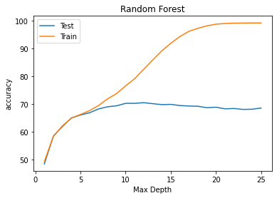

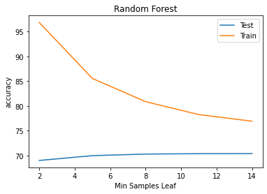

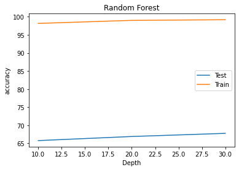

```
Best possible max_depth: 12
Best possible min_samples_leaf: 14
Best possible n_estimators: 30
Best possible accuracy: 67.76666666666667
```

```python
best_RF_max_depth = -1
best_RF_min_samples_leaf = -1
best_RF_n_estimators = -1

def random_forest_tuning(X_train , Y_train , X_test , Y_test):
    train_acc = []
    test_acc = []
    global best_RF_max_depth
    global best_RF_min_samples_leaf
    global best_RF_n_estimators
    max_acc = float("-inf")
    l = [2, 5, 8, 11, 14]
    ne = [10, 20, 30]

    for i in list(range(1 , 26)):
        RF = RandomForestClassifier(max_depth = i)
        RF = RF.fit(X_train, Y_train)
        test_predict = RF.predict(X_test)
        train_predict = RF.predict(X_train)
        train_acc.append(float((accuracy_score(Y_train, np.round(abs(train_predict)))) * 100))
        test_acc.append(float((accuracy_score(Y_test, np.round(abs(test_predict)))) * 100))
        if(float((accuracy_score(Y_test, np.round(abs(test_predict)))) * 100) > max_acc):
            max_acc = float((accuracy_score(Y_test, np.round(abs(test_predict)))) * 100)
            best_RF_max_depth = i
    plt.plot(list(range(1, 26)), test_acc, label='Test')
    plt.plot(list(range(1, 26)), train_acc, label='Train')
    plt.ylabel('accuracy')
    plt.xlabel('Max Depth')
    plt.title('Random Forest')
    plt.legend()
    plt.show()
    test_acc.clear()
    train_acc.clear()
    max_acc = float("-inf")

    for i in l:
        RF = RandomForestClassifier(min_samples_leaf = i)
        RF = RF.fit(X_train, Y_train)
        test_predict = RF.predict(X_test)
        train_predict = RF.predict(X_train)
        train_acc.append(float((accuracy_score(Y_train, np.round(abs(train_predict)))) * 100))
        test_acc.append(float((accuracy_score(Y_test, np.round(abs(test_predict)))) * 100))
        if(float((accuracy_score(Y_test, np.round(abs(test_predict)))) * 100) > max_acc):
            max_acc = float((accuracy_score(Y_test, np.round(abs(test_predict)))) * 100)
            best_RF_min_samples_leaf = i
    plt.plot(list(range(2, 15, 3)), test_acc, label='Test')
    plt.plot(list(range(2, 15, 3)), train_acc, label='Train')
    plt.ylabel('accuracy')
    plt.xlabel('Min Samples Leaf')
    plt.title('Random Forest')
    plt.legend()
    plt.show()
    test_acc.clear()
    train_acc.clear()
    max_acc = float("-inf")

    for i in ne:
        RF = RandomForestClassifier(n_estimators = i)
        RF = RF.fit(X_train, Y_train)
        test_predict = RF.predict(X_test)
        train_predict = RF.predict(X_train)
        train_acc.append(float((accuracy_score(Y_train, np.round(abs(train_predict)))) * 100))
        test_acc.append(float((accuracy_score(Y_test, np.round(abs(test_predict)))) * 100))
        if(float((accuracy_score(Y_test, np.round(abs(test_predict)))) * 100) > max_acc):
            max_acc = float((accuracy_score(Y_test, np.round(abs(test_predict)))) * 100)
            best_RF_n_estimators = i
    plt.plot(list(range(10, 31, 10)), test_acc, label='Test')
    plt.plot(list(range(10, 31, 10)), train_acc, label='Train')
    plt.ylabel('accuracy')
    plt.xlabel('Depth')
    plt.title('Random Forest')
    plt.legend()
    plt.show()
    test_acc.clear()
    train_acc.clear()

    print("Best possible max_depth: " + str(best_RF_max_depth))
    print("Best possible min_samples_leaf: " + str(best_RF_min_samples_leaf))
    print("Best possible n_estimators: " + str(best_RF_n_estimators))
    print("Best possible accuracy: " + str(max_acc))

print("test_size = 0.20\n")
random_forest_tuning(X_train , Y_train , X_test , Y_test)
```